# 24_1s_MTM1013T11_AP02_AeB_AndreGoncalvesdaSilva

#### MTM1013 - MÉT. NUM. E COMPUTACIONAIS Prof. Charles R. P. Szinvelski

### AP(02) - Parte A e B

#### 1s/UFSM Período: 12-19/08/24

#### Acadêmico: André Gonçalves da Silva Matrícula: 202210071 Curso/Turma: 123/11

As questões da Avaliação Parcial 02 (AP(02)) tem por finalidade a aplicação direta dos aspectos teóricos e práticos dos métodos numéricos abordados na disciplina (Integração Numérica, Ajuste Funcional e Resolução de EDO(s) e recursos de programação em linguagem PYTHON 3 empregados nas respectivas implementaçãos e cálculo numérico). A produção do arquivo-resposta seguirá os moldes da produção dos arquivos dos enunciados, nos formatos IPYNB e PDF e ambos deverão ser entregues via TAREFA aberta no MOODLE para a AP(02) de 19/08/2024.

Observa-se que a Parte A dessa avaliação substitui as mini-avaliações QUESTÃO (01), QUESTÃO (02) e QUESTÃO(03), substituição decorrente a excepcionalidade da alteração do calendário acadêmico de 2024.

OBSERVAÇÕES

- Salienta-se que observância da nomeação dos arquivos IPYNB e PDF (ver abaixo) e informações do cabeçalho (prencher devidamente) serão partes constituinte do escore (divisões sucessivas por 2):
  - 24_1s_MTM1013T11_AP02_AeB_NomeSobrenome.ipynb;
  - 24_1s_MTM1013T11_AP02_AeB_NomeSobrenome.pdf;
- Os algoritmos que devem ser empregados para as implementações em linguagem PYTHON 3 e *testes de mesas* são os algoritmos dados pelo material didático disponibilizado nos repositórios [MEGA](https://mega.nz/file/11sk1L4T#3isyksEZmWwo-fBnq2-XaCAjUQ7t-K8jf30P3m0wEbg) e [DRIVE](https://drive.google.com/file/d/1UWgdXksWXlOd880PWyMYGj2Jqlgeyu0b/view?usp=sharing) e não os sendo as respostas serão desconsideradas. Ressalta-se que os algoritmos do Material Didático são adequações dos algoritmos apresentados em Campos Filho (2018)[⁰], os quais podem ser utilizados para a implementação ou da Burden e Fayres (2016)[¹];
- A elaboração das questões buscará caracterizações personalizadas para cada aluno, fato que resultará em um diversificado conjunto de situações-testes para a exploração dos aspectos teóricos e práticos da disciplina em detrimento, eventualmente, da aplicabilidade do tema abord ado na questão.

[⁰]: Filho, Frederico Ferreira C. Algoritmos Numéricos - Uma Abordagem Moderna de Cálculo Numérico, 3ª edição. Disponível em: [Minha Biblioteca](https://integrada.minhabiblioteca.com.br/reader/books/9788521635659/epubcfi/6/2%5B%3Bvnd.vst.idref%3Dcover%5D!/4/2/2%4050:43), Grupo GEN, 2018. Ainda, há exemplares na BSCCNE.

[¹]: Burden, Richard, L. et al. Análise Numérica - Tradução da 10ª edição norte-americana. Disponível em: [Minha Biblioteca](https://integrada.minhabiblioteca.com.br/reader/books/9788522123414/pageid/785), (3rd edição). Cengage Learning Brasil, 2016.

###### Obtenção de dados para elaboração das questões.

Ao considerar o meu número de matrícula na UFSM, 3332882, monta-se a tabela

| d1 | d2 | d3 | d4 | d5 | d6 | d7 | d8 | d9 | d10 |
| --- | --- | --- | --- | --- | --- | --- | --- | --- | --- |
| 0 | 0 | 0 | 3 | 3 | 3 | 2 | 8 | 8 | 2 |

e sobre essas informações, colocam-se as seguintes elaborações:

(I) Dedução dos parâmetros.

- $a=d5=3$ - caso $a=0$, colocar $a=+1$;
- $b=d6=3$ - caso $b=0$ ou $b=a$, colocar $b=+1$;
- $c=(d1+d2+d3+d4)=(0+0+0+3)=3$;
- $d=(d7+d8+d9+d10)=(2+8+8+2)=20 \overbrace{\Rightarrow}^{d \geq 10} d=(2+0)=2$;
- $Dados=[a,b,c,d]=[3,1,3,2]$;
- $r_0=min\{a,b,c,d\}=1$;

(II) Sabe-se do estudo de fluidos que a quantidade de fluido por unidade de tempo $[(u.c.)^3/(u.t.)]$ que atravessa esta secção uma seção circular de raio $r_0=a$ é dado por:

$$Q=\frac{V}{t};$$

O volume pode ser descrito $V=Ad$, com $A$ a área da seção transversal circular e $d$ a profundidade desse quantidade que se quer medir ([ver ilustração](https://cdn.kastatic.org/ka-perseus-images/0585b956c3af0284cb5fb0f72e16215286d2dcd1.png))[²], logo

$$Q=\frac{V}{t}=\frac{Ad}{t}=A\frac{d}{t}=Av_{fluido},$$

com $v_{fluido}=d/t$ a velocidade do fluido;

Sobre essa análise qualitativa do processo de medição da quantidade de fluido que passa pela seção transversal circular, pode-se montar formulações mais precisas para a quantificação dessa quantidade $Q$, como segue:

- Da disciplina de Cálculo B (ou II) problemas associados à quantificação do fluxo de um fluido através de uma superfície $S$ é dada pela integral de superfície: $$\begin{aligned} \mbox{FLUXO} & =\iint_S \mathbf{v}(x,y,z)\cdot \mathbf{n} dS= \iint_{D_{xz}} \left(v_x,v_y,v_z\right)\cdot \overbrace{\dfrac{\mathbf{N}}{||\mathbf{N}||}}^{\mathbf{n}}\underbrace{||\mathbf{N}|| dA}_{dS} \\ { } & = \iint_{D_{xz}} \left(v_x,v_y,v_z \right)\cdot (n_x,n_y,n_z) dA = \iint_{D_{xz}} (v_xn_x+v_yn_y+v_zn_z) dA \end{aligned},$$ cuja resolução dará a quantidade de fluido que passa pela secção por unidade de tempo;
- Considere o campo de velocidades do fluido dado por $\mathbf{v}(x,y,z)=\left(0,b\left(1-\tfrac{\sqrt{x^2+z^2}}{c}\right)^{1/7},0\right)$, com o centro do tubo de raio $r_0$ alinhado com o vetor normal $\mathbf{n}=(n_x,n_y,n_z)=(0,1,0)=\mathbf{j}=\frac{\mathbf{N}}{||\mathbf{N}||}$ a superfície de corte seccional descrita acima;
- Devido a simetria circular da seção transversal, emprega-se coordenadas polares para a descrição do campo de velocidades e no cálculo da quantidade de fluxo, ie,
  - $\mathbf{v}(x,y,z)=\left(0,b\left(1-\tfrac{\sqrt{x^2+z^2}}{c}\right)^{1/7},0\right)\equiv \left(0, b\left(1-\tfrac{r}{c}\right)^{1/7} ,0 \right) \Rightarrow v_y(r,\theta) = v(r) = b\left(1-\tfrac{r}{r_0}\right)^{1/7}$;
  - Conforme dados acima, segue que $$ \begin{aligned} Q & =\iint_{D_{xz}} v_y(x,z)dA, \: D_{xz}:=\{ (x,z) \in \mathbb{R}^2 | 0 \leq x^2+z^2 \leq r_0 \} \\ { } & \equiv \iint_{D_{r\theta}} v_y(r,\theta)dA, \: D_{r\theta}:=\{ (r,\theta) \in \mathbb{R}^2 | 0 < r < r_0 \wedge 0 \leq \theta < 2\pi \} \: (x=r\cos{\theta}, z=r \operatorname{sen}{\theta}) \\ { } & =\int_{0}^{r_0} \int_{0}^{2\pi} v_y(r,\theta) rdr d\theta = \int_{0}^{2\pi} d \theta \int_{0}^{r_0} r v_y(r,\theta) dr = 2 \pi \int_{0}^{r_0} r v_y(r,\theta) dr= 2 \pi \int_{0}^{r_0} r v(r) dr\end{aligned}.$$
- Os itens acima, com a lista de de Dados aplicáveis:
  - $\mathbf{v}(r,y,\theta)=\left(0,1\left(1-\tfrac{r}{r_0}\right)^{1/7},0\right)=\left(0,\left(1-\frac{r}{1}\right)^{1/7},0\right)=\left(0,\left(1-r\right)^{1/7},0\right)$;
  - $D_{xz}:=\{ (x,z) \in \mathbb{R}^2 | 0 \leq x^2+z^2 \leq r_0 \} \equiv D_{xz}:=\{ (x,z) \in \mathbb{R}^2 | 0 \leq x^2+z^2 \leq 1 \}$;

(III) Gere as tabelas, com a seguinte caracterização para a funçao $v(r)$ e o integrando $rv(r)$:

- (A) Os sete primeiros pontos igualmente afastados para o intervalo $[0;0,8r_0]$;
- (B) Os cinco últimos pontos igualmente afastados para o intervalo $[0,8r_0;r_0]$;

E a partir destas listas montadas, plotar estes pares ordenados e as funções geratrizes via biblioteca MATPLOTLIB;

Obs.: Os dados obtidos formarão uma tabela no formato:

| $r$ | $0$ | $\ldots$ | $0,8r_0$ | $\ldots$ | $r_0$ |
| --- | --- | --- | --- | --- | --- |
| $v(r)$ | $b $ | $\ldots$ | $v(0,8r_0)$ | $\ldots$ | $v(r_0)$ |
| $rv(r)$ | $0 $ | $\ldots$ | $(0,8r_0)v(0,8r_0)$ | $\ldots$ | $r_0 v(r_0)$ |

E os gráficos via WolframAlpha, para os dados acima:

- [Gráfico de $v(r)$](https://www.wolframalpha.com/input?i=plot+1%281-r%2F1%29%5E%281%2F7%29%2C+r+%3D+0+..+1);
- [Gráfico do integrando $rv(r)$](https://www.wolframalpha.com/input?i=plot+1r%281-r%2F1%29%5E%281%2F7%29%2C+r+%3D+0+..+1);

(IV) A partir de (I), montar o PVI: $\left\{ \begin{aligned} {} & ay'=b+\frac{cy}{dx}, x \in [1,2] \\ {} & y(1)=2 \: (h=0,05) \end{aligned} \right. \Leftrightarrow \left\{ \begin{aligned} {} & 3y'=1+\frac{3y}{2x}\\ {} & y(1)=2 \end{aligned} \right. $

(V) Para gráficos pode-se usar as páginas tutoriais: [MATPLOLIB](https://matplotlib.org/stable/index.html), [SYMPY](https://www.tutorialspoint.com/sympy/sympy_plotting.htm) ou [SYMPY(2)](https://docs.sympy.org/latest/modules/plotting.html).

[²]: KHAN ACADEMY. O que é taxa de fluxo de volume? Disponível em: [<https://pt.khanacademy.org/science/physics/fluids/fluid-dynamics/a/what-is-volume-flow-rate >](https://pt.khanacademy.org/science/physics/fluids/fluid-dynamics/a/what-is-volume-flow-rate). Acesso em: 12/08/2024.

### QUESTÕES - PARTE A

**1) (1,0 ponto)** Faça o que se pede, a partir das intruções acima:

**1.1) (0,2 ponto [Dados])** Informe sua matrícula como uma lista ($matricula=[d1,d2,d3,d4,d5,d6,d7,d8,d9,d10]$), bem como a lista de parâmetros Dados;

**1.2) (0,2 ponto [Dados])** Monte a integral a ser resolvida em $r$ (ver (II)) e detaque a função $v$;

**1.3) (0,3 ponto [Dados])** Informe as tabelas em (III) em forma de lista e plote os diagramas de dispersão associados;

**1.4) (0,3 ponto [Dados])** Informe o PVI em (IV) para os parâmetros associados à sua matrícula;

**2) (1,0 ponto)** Sobre o Item (II) e a Questão 1.2, faça o que se pede:

**2.1) (0,25 ponto [Dados])** Plote o campo de direções tridimensionais no domínio $D_{xz}$, bem como a superfície $v_y(r,\theta)= v(r)=b\left(1-\frac{r}{c}\right)^{1/7} $ definida neses domínio;

**2.2) (0,25 ponto [Dados])** Plote asfunções $v(r)$ e $rv(r)$ confrontando com os dados tabelados no intervalo completo;

**2.3) (0,5 ponto [Dados])** Informe o resultado da integral em $r$ com 9 casas de precisão e informe $Q$;

**3) (1,5 pontos)** A partir dos dados em 1.3) e (III), faça o que se pede:

**3.1) (0,5 ponto)** Utilize o MMQ para encontrar os ajustes funcionais nos respectivos intervalos dados pelas tabelas acima;

(Sugestão: Utilize uma ajuste quadrático para o primeiro subintervalo e um ajuste exponencial para o segundo subintervalo.)

**3.2) (0,5 ponto)** Plote essas representações confrontando com os Diagramas de Dispersão dados;

**3.3) (0,5 ponto)** Com as informações obtidas em 3.1, calcule as integrais nos respectivos subintervalos e informe $Q$;

**4) (1,0 ponto)** Resolva o PVI (1.4) (ver (IV)) pelo Método de Heun e apresenta uma tabela, de 10 em 10 valores das soluções, que confronte a solução numérica com a solução analítica, bem como o erro real associado. Faça um gráfico comparando a solução analítica *versus* a solução numérica e as linhas de fluxo associadas;

### QUESTÕES - PARTE B

**OBSERVAÇÃO:** Colocar os documentos IPYNB e PDF da resolução no espaço TAREFA do MOODLE aberta, caso queira entregar o arquivo-resposta com esses recursos computacionais. Caso se resolva via Google COLAB, colocar link compartilhado sem restrições de acesso e também o arquivo PDF associado.

```python
import numpy as np
import math
from math import trunc
import matplotlib.pyplot as plt
#se tiver dando problema aqui é só comentar essa linha seguinte
from IPython.display import Markdown as md
```

```python
d1 = 0
d2 = 2
d3 = 0
d4 = 2
d5 = 2
d6 = 1
d7 = 0
d8 = 0
d9 = 7
d10 = 1

a = d5
if a == 0:
    a = 1

b = d6
#se a == b == 1 como que fica??
if b == 0 or b == a:
    b = 1

c = d1 + d2 + d3 + d4
d = d7 + d8 + d9 + d10

r0 = np.min([a, b, c, d])
```

## Resposta da 1.1

```python
print("Matrícula = %s"%([d1, d2, d3, d4, d5, d6, d7, d8, d9, d10]))
print("Dados = %s"%([a, b, c, d]))
print("r_0 = %s"%r0)
```

```
Matrícula = [0, 2, 0, 2, 2, 1, 0, 0, 7, 1]
Dados = [2, 1, 4, 8]
r_0 = 1
```

## Resposta da 1.2

A integral a ser resolvida é \begin{equation} Q = 2\pi \int_0^{r_0} r v(r) dr, \end{equation} onde \begin{equation} v(r, y, \theta) = v_y(r) = b \bigg( 1 - \frac{r}{r_0} \bigg)^{1/7}. \end{equation}

No meu caso:

\begin{equation} Q = 2\pi \int_0^{1} r v(r) dr, \end{equation}

\begin{equation} v(r) = (1 - r)^{1/7}. \end{equation}

```python
#tem como fazer as equações em latex com as variaveis do python
Qstring = (r"\begin{equation} Q = 2\pi \int_0^{%d} r v(r) dr, \end{equation}")
vstring = (r"\begin{equation} v(r) = {%d} \bigg(1 - \frac{r}{%d} \bigg)^{1/7}. \end{equation}")
md(Qstring%(r0) + "\n\n" + vstring%(b,r0))
```

\begin{equation} Q = 2\pi \int_0^{1} r v(r) dr, \end{equation}

\begin{equation} v(r) = {1} \bigg(1 - \frac{r}{1} \bigg)^{1/7}. \end{equation}

## Resposta da 1.3

```python
v = lambda r: b*(1 - r/r0)**(1/7)
r1 = np.linspace(0, 0.8*r0, 7)
r2 = np.linspace(0.8*r0, r0, 5)

vrvals1 = v(r1)
vrvals2 = v(r2)

rvrvals1 = r1*vrvals1
rvrvals2 = r2*vrvals2

#começa no 1 os segundos porque não quero o ponto com r = 0.8*r0 sendo repetido
rvals = np.concatenate((r1, r2[1:]))
vrvals = np.concatenate((vrvals1, vrvals2[1:]))
rvrvals = np.concatenate((rvrvals1, rvrvals2[1:]))

float_formatter = "{:.3f}".format
np.set_printoptions(formatter={'float_kind':float_formatter})
print("Tabelas da (III) em forma de lista (1a linha: valores de r/r0, 2a linha: valores de v(r), 3a linha: valores de r*v(r)):")
print(rvals)
print(vrvals)
print(rvrvals)
```

```
Tabelas da (III) em forma de lista (1a linha: valores de r/r0, 2a linha: valores de v(r), 3a linha: valores de r*v(r)):
[0.000 0.133 0.267 0.400 0.533 0.667 0.800 0.850 0.900 0.950 1.000]
[1.000 0.980 0.957 0.930 0.897 0.855 0.795 0.763 0.720 0.652 0.000]
[0.000 0.131 0.255 0.372 0.478 0.570 0.636 0.648 0.648 0.619 0.000]
```

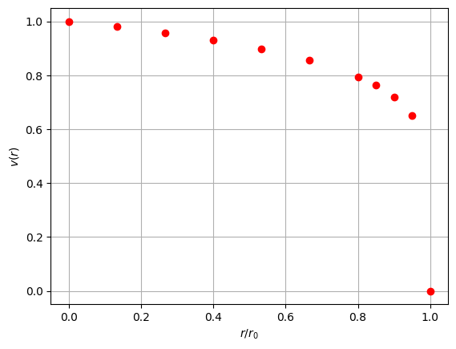

```python
plt.plot(rvals, vrvals, "ro", label="$v(r)$")
plt.xlabel("$r/r_0$")
plt.ylabel("$v(r)$")
plt.grid()
plt.show()
```

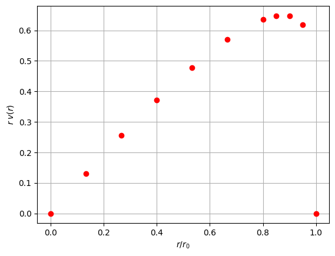

```python
plt.plot(rvals, rvrvals, "ro", label="r v(r)")
plt.xlabel("$r/r_0$")
plt.ylabel("$r \; v(r)$")
plt.grid()
plt.show()
```

Vemos que é na realidade um caso de escoamento de um fluido viscoso no tubo, perto das fronteiras do tubo o fluido tem menos velocidade.

## Resposta da 1.4

O PVI é dado por:

\begin{equation} \left\{ \begin{array}{l} ay' = b + \frac{cy}{dx}, x \in [1,2] \\ y(1) = 2, (h = 0,05) \end{array} \right. , \end{equation} com os meus dados: \begin{equation} \left\{ \begin{array}{l} 2y' = 1 + \frac{4y}{8x}, x \in [1,2] \\ y(1) = 2, (h = 0,05) \end{array} \right. \Leftrightarrow \left\{ \begin{array}{l} 2y' = 1 + \frac{y}{2x} \\ y(1) = 2 \end{array} \right. . \end{equation}

## Resposta da 2.1

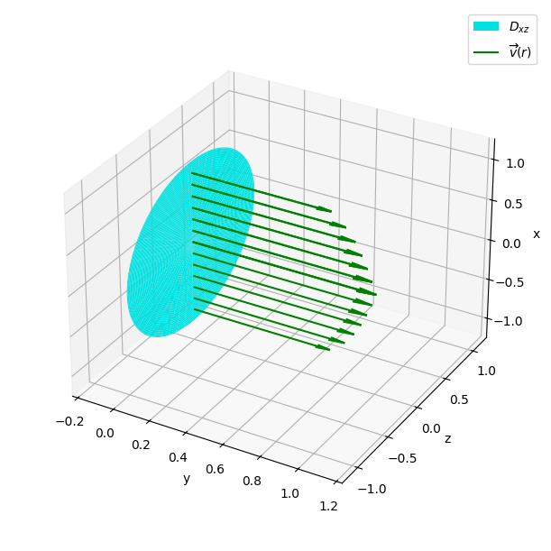

```python
rparam = np.linspace(0, r0, 100)
thetaparam = np.linspace(0, 2*np.pi, 100)
rmesh, thetamesh = np.meshgrid(rparam, thetaparam)

Dx = rmesh*np.cos(thetamesh)
Dy = 0*rmesh
Dz = rmesh*np.sin(thetamesh)

rparamvec = np.linspace(0, r0, 8)
thetaparamvec = np.linspace(0, 2*np.pi, 3)

rmeshvec, thetameshvec = np.meshgrid(rparamvec, thetaparamvec)

x = rmeshvec*np.cos(thetameshvec)
y = 0*rmeshvec
z = rmeshvec*np.sin(thetameshvec)
vxvec = 0*rmeshvec
vyvec = (b*(1 - rmeshvec/r0)**(1/7))
vzvec = 0*rmeshvec

fig = plt.figure(figsize=(8, 6), layout="constrained")
ax = fig.add_subplot(111, projection='3d')

ax.plot_surface(Dx, Dy, Dz, alpha=1.0, color="cyan")
ax.quiver(x, y, z, vxvec, vyvec, vzvec, color="green", length=1.0, arrow_length_ratio=0.1, normalize=False)

ax.view_init(vertical_axis="x")
ax.set_box_aspect(aspect=None, zoom=0.9)
ax.set_xlabel("x")
ax.set_ylabel("y")
ax.set_zlabel("z")
ax.set_xlim3d(-1.2, r0 + 0.2)
ax.set_ylim3d(-0.2, r0 + 0.2)
ax.set_zlim3d(-1.2, r0 + 0.2)
ax.legend(["$D_{xz}$", "$\overrightarrow{v}(r)$"])
plt.show()
```

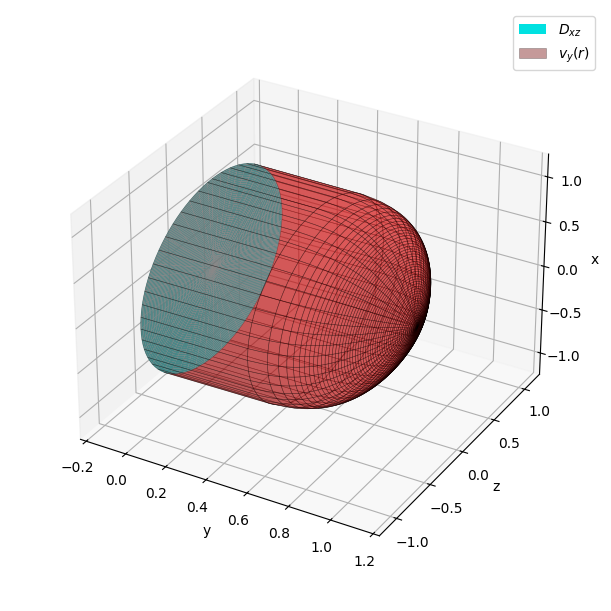

```python
rparam = np.linspace(0, r0, 100)
thetaparam = np.linspace(0, 2*np.pi, 100)
rmesh, thetamesh = np.meshgrid(rparam, thetaparam)

Dx = rmesh*np.cos(thetamesh)
Dy = 0*rmesh
Dz = rmesh*np.sin(thetamesh)

vx = rmesh*np.cos(thetamesh)
vy = (b*(1 - rmesh/r0)**(1/7))
vz = rmesh*np.sin(thetamesh)

fig = plt.figure(figsize=(8, 6), layout="constrained")
ax = fig.add_subplot(111, projection='3d')

ax.plot_surface(Dx, Dy, Dz, alpha=1.0, color="cyan")
ax.plot_surface(vx, vy, vz, alpha=0.4, color="red", edgecolor="Black", lw=0.4)

ax.view_init(vertical_axis="x")
ax.set_box_aspect(aspect=None, zoom=0.9)
ax.set_xlabel("x")
ax.set_ylabel("y")
ax.set_zlabel("z")
ax.set_xlim3d(-1.2, r0 + 0.2)
ax.set_ylim3d(-0.2, r0 + 0.2)
ax.set_zlim3d(-1.2, r0 + 0.2)
ax.legend(["$D_{xz}$", "$v_y(r)$"])
plt.show()
```

## Resposta da 2.2

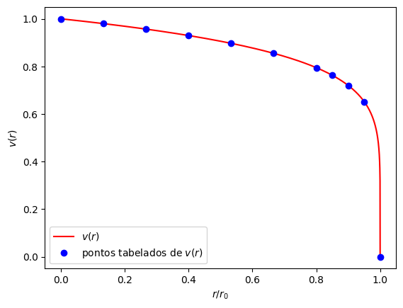

```python
#não é exatamente um plot smooth, daria para fazer algo talvez mais suave com sympy
rsmooth1 = np.linspace(0, 0.9*r0, 100)
rsmooth2 = np.linspace(0.9*r0, r0, 300)
rsmooth = np.concatenate((rsmooth1, rsmooth2[1:]))
vsmooth = v(rsmooth)

plt.plot(rsmooth, vsmooth, "r-", label="$v(r)$")
plt.plot(rvals, vrvals, "bo")
plt.legend(["$v(r)$", "pontos tabelados de $v(r)$"])
plt.xlabel("$r/r_0$")
plt.ylabel("$v(r)$")
plt.show()
```

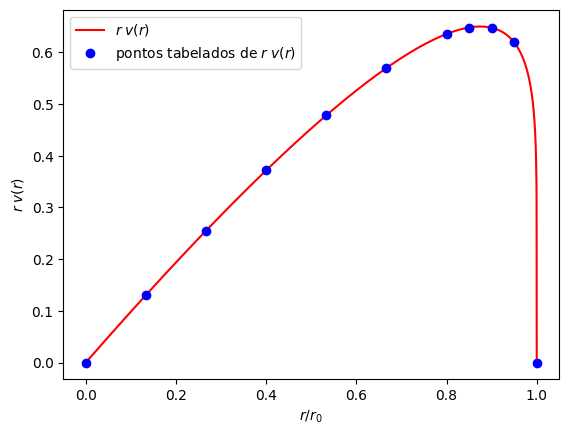

```python
rvsmooth = rsmooth*vsmooth

plt.plot(rsmooth, rvsmooth, "r-", label="$r \; v(r)$")
plt.plot(rvals, rvrvals, "bo")
plt.legend(["$r \; v(r)$", "pontos tabelados de $r \; v(r)$"])
plt.xlabel("$r/r_0$")
plt.ylabel("$r \; v(r)$")
plt.show()
```

Retomando a integral:

\begin{equation} Q = 2\pi \int_0^{1} r v(r) dr, \end{equation}

\begin{equation} v(r) = (1 - r)^{1/7}. \end{equation}

```python
#código de newton cotes

def newtoncotes(f, a, b, n, m):
    d = [2., 6., 8., 90., 288., 840., 17280., 28350.]
    c = [1., 1., 4., 1., 3., 7., 32., 12., 19., 75., 50., 41., 216., 27., 272., 751., 3577., 1323., 2989., 28350., 989., 588., -928., 10496., -4540.]

    conderro = 0
    intgr = 0

    if n < 1 or n > 8:
        conderro += 1

    if m % n != 0:
        conderro += 2

    if conderro != 0:
        print("condERRO = %s"%conderro)
        return None

    p = trunc(0.25*(n*(n + 2) + (n%2)))
    h = (b - a)/m

    for i in range(m+1):
        x = a + i*h
        y = f(x)
        j = p + trunc(0.5*n - abs((i%n) - 0.5*n))
        k = 1 + trunc((n - (i%n))/n) - trunc((m - (i%m))/m)
        intgr += y*c[j]*k

    intgr *= n*h/d[n-1]

    return intgr
```

## Resposta da 2.3

```python
v = lambda r: b*(1 - r/r0)**(1/7)
f = lambda r: r*v(r)

#essa é uma integral que pode ser resolvida analiticamente
Iteo = 0.408333333 #com 9 casas decimais
I = newtoncotes(f, 0, r0, 1, 10)
n = 10
#o algorítimo implementado é o mesmo da apostila e tecnicamente não tem nada errado em fazer dessa maneira,
#apesar de que deve haver um método de subdividir o intervalo e usar outras formulas de interpolação pro
#newton cotes.
#ps: em Julia e Fortran esse mesmo código roda em menos de 4s, em comparação com os mais de 2 minutos em Python
while abs(I - Iteo) > 1e-9 and n < 100000000:
    n *= 10
    I = newtoncotes(f, 0, r0, 1, n)

print("I = %.9f"%I)
print("n = %d"%n)
```

[output not shown]

```python
Q = 2*np.pi*I
print("Q = %.9f"%Q)
```

```
Q = 2.565633999
```

```python
#código de sistemas lineares
def LUdecomp(A):
    n = A.shape[0]
    m = A.shape[1]

    pivot = np.zeros(n)
    for i in range(n):
        pivot[i] = i+1

    det = 1
    for j in range(0,n-1):
        p = j
        Amax = abs(A[j,j])
        for k in range(j+1,n):
            if abs(A[k,j]) > Amax:
                Amax = abs(A[k,j])
                p = k

        if p != j:
            for k in range(0,m):
                t = A[j,k]
                A[j,k] = A[p,k]
                A[p,k] = t

            s = pivot[j]
            pivot[j] = pivot[p]
            pivot[p] = s
            det = -det

        det = det*A[j,j]
        if A[j,j] != 0:
            r = 1/A[j,j]
            for i in range(j+1,n):
                mult = A[i,j]*r
                A[i,j] = mult
                for k in range(j+1,m):
                    A[i,k] = A[i,k] - mult*A[j,k]

    det = det*A[n-1,n-1]
    return (A, det, pivot)

def getL(LU):
    n = LU.shape[0]
    m = LU.shape[1]

    L = np.zeros((n,m))
    for i in range(n):
        for j in range(m):
            if i == j:
                L[i,j] = 1
            elif i > j:
                L[i,j] = LU[i,j]

    return L

def getU(LU):
    n = LU.shape[0]
    m = LU.shape[1]

    U = np.zeros((n,m))
    for i in range(n):
        for j in range(m):
            if i <= j:
                U[i,j] = LU[i,j]

    return U

def solveL(L, pivot, b):
    n = L.shape[0]

    y = np.zeros(n)
    k = int(pivot[0])
    y[0] = b[k-1]
    for i in range(1,n):
        soma = 0
        for j in range(0,i):
            soma = soma + L[i,j]*y[j]

        k = int(pivot[i])
        #tive que fazer essa adaptação porque o algorítmo do material não é genérico o suficiente
        #para permitir que seja qualquer matrix triangular inferior
        y[i] = (b[k-1] - soma)/L[i,i]

    return y

def solveU(U, y):
    n = U.shape[0]
    x = np.zeros(n)

    x[n-1] = y[n-1]/U[n-1,n-1]
    for i in reversed(range(0,n-1)):
        soma = 0
        for j in range(i+1,n):
            soma = soma + U[i,j]*x[j]

        x[i] = (y[i] - soma)/U[i,i]

    return x

def solveLU(A, b):
    LU, det, pivot = LUdecomp(A)
    L = getL(LU)
    U = getU(LU)
    y = solveL(L, pivot, b)
    x = solveU(U, y)
    return x

def choleskydecomp(A):
    n = A.shape[0]

    conderro = 0
    det = 1
    r = 1
    t = 1
    soma = 0
    for j in range(0,n):
        soma = 0
        for k in range(0,j):
            soma = soma + A[j,k]**2

        t = A[j,j] - soma
        if t > 0:
            A[j,j] = math.sqrt(t)
            r = 1/A[j,j]
            det = det*t
        else:
            conderro = 1
            print("Erro: matriz não definida positiva")
            return (A, conderro, det)

        for i in range(j+1,n):
            soma = 0
            for k in range(0,j):
                soma = soma + A[i,k]*A[j,k]

            A[i,j] = (A[i,j] - soma)*r
            #algorítmo no material retornava uma matriz que não era triangular inferior (ele não mexia nos elementos acima da diagonal)
            A[j,i] = 0

    return (A, conderro, det)

def solvecholesky(A, b):
    G, conderro, det = choleskydecomp(A)
    #cholesky não faz pivoteamento, pivot vai ser só [1,2,3]
    pivot = np.arange(1, A.shape[0]+1)
    y = solveL(G, pivot, b)
    x = solveU(G.T, y)
    return x

def solvegauss_seidel(A, b, tol, itermax):
    n = A.shape[0]
    x = np.zeros(n)
    v = np.zeros(n)
    for i in range(0,n):
        r = 1/A[i,i]
        for j in range(0,n):
            if i != j:
                A[i,j] = A[i,j]*r

        #A[i,i] = 0
        b[i] = b[i]*r
        x[i] = b[i]

    iter = 0
    normarel = 1
    while iter <= itermax:
        iter = iter + 1
        for i in range(0,n):
            soma = 0
            for j in range(0,n):
                if i != j:
                    soma = soma + A[i,j]*x[j]

            v[i] = x[i]
            x[i] = b[i] - soma

        normanum = 0
        normaden = 0
        for i in range(0,n):
            t = abs(v[i] - x[i])
            normanum = normanum + t**2
            normaden = normaden + abs(v[i])**2

        normarel = math.sqrt(normanum/normaden)
        if normarel <= tol:
            conderro = 0
        else:
            conderro = 1


    return x, normarel, conderro
```

```python
#código de formatação de matrizes
def formatacaough(A):
    for i in range(A.shape[0]):
        if len(A.shape) == 2:
            for j in range(A.shape[1]):
                print("[{0:^9}]".format("%.3g" % A[i,j]), end='')
        else:
            print("[{0:^9}]".format("%.3g" % A[i]), end='')

        print()
```

```python
#código de ajuste funcional
#não tem um algorítmo de ajuste funcional explícito na apostila, mas utilizei o que foi descrito no moodle
def discretenorm(u, v):
    if len(u) != len(v):
        raise ValueError("Vectors must have the same length")

    return sum([u[i]*v[i] for i in range(len(u))])

def discretepolynfit(x, y, n):
    M = np.zeros((n+1,n+1))
    b = np.zeros(n+1)
    for i in range(n+1):
        for j in range(n+1):
            M[i,j] = discretenorm(x**i, x**j)

        b[i] = discretenorm(y, x**i)

    #talvez tenha outros métodos mais eficientes de resolver esse sistema, mas como o LU e gauss compacto
    #ta funcionando bem aqui eu vou manter
    return solveLU(M, b)

def discreteexpfit(x, y):
    M = np.zeros((2,2))
    b = np.zeros(2)
    for i in range(2):
        for j in range(2):
            M[i,j] = discretenorm(x**i, x**j)

        b[i] = discretenorm(np.log(y), x**i)

    return solveLU(M, b)
```

Temos a tabela de dados:

```python
#precisa ter a celula onde isso é apresentado rodada
print(rvals)
print(vrvals)
print(rvrvals)
```

```
[0.000 0.133 0.267 0.400 0.533 0.667 0.800 0.850 0.900 0.950 1.000]
[1.000 0.980 0.957 0.930 0.897 0.855 0.795 0.763 0.720 0.652 0.000]
[0.000 0.131 0.255 0.372 0.478 0.570 0.636 0.648 0.648 0.619 0.000]
```

Vou fazer um ajuste de MMC de ordem 4 no primeiro subintervalo ($[0, 0.8r_0]$) e um ajuste logaritmo no segundo subintervalo ($[0.8r_0, r_0]$):

```python
interval1 = rvals[0:7]
interval2 = rvals[6:12]
vrvals1 = vrvals[0:7]
vrvals2 = vrvals[6:12]
```

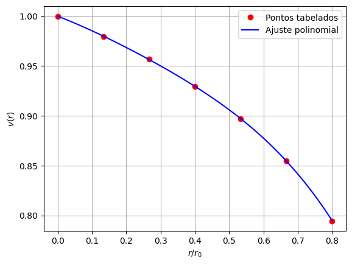

```python
n1 = 4
coeff1 = discretepolynfit(interval1, vrvals1, n1)
ffourth1 = lambda x: sum([coeff1[i]*x**i for i in range(n1+1)])
xquad1 = np.linspace(interval1[0], interval1[-1], 100)
plt.plot(interval1, vrvals1, "ro")
plt.plot(xquad1, ffourth1(xquad1), "b-")
plt.xlabel("$r/r_0$")
plt.ylabel("$v(r)$")
plt.legend(["Pontos tabelados", "Ajuste polinomial"])
plt.grid()
plt.show()
```

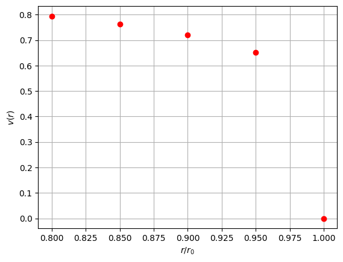

```python
plt.plot(interval2, vrvals2, "ro", label="$v(r)$")
plt.xlabel("$r/r_0$")
plt.ylabel("$v(r)$")
plt.grid()
plt.show()
```

Vou tentar linearizar esse gráfico supondo a seguinte forma funcional de $v(r)$:

\begin{equation} v(r) = a_1 \ln(1 - r) + a_2, \end{equation} onde $r = r/r_0$. Conseguimos a partir de uma função do tipo imitar a queda súbita que aparece em $r = 1$ e, apesar de haver uma indeterminação no ponto em que o argumento do logaritmo vai a zero, ainda conseguiremos usar essa forma para aproximar a integral desejada (ainda é possível integrar uma função do tipo).

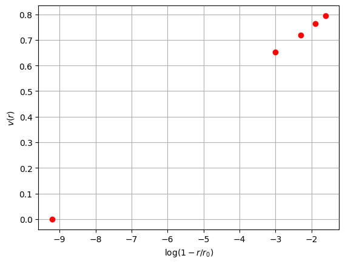

```python
x1 = interval2
# podemos redefinir x para que seja menor que esse log ou então mudar o 1 dentro do argumento do log
#x[-1] = 0.9999
newx1 = np.log(1.0000001 - x1)

plt.plot(newx1, vrvals2, 'ro')
plt.xlabel("$\log(1 - r/r_0)$")
plt.ylabel("$v(r)$")
plt.grid()
plt.show()
```

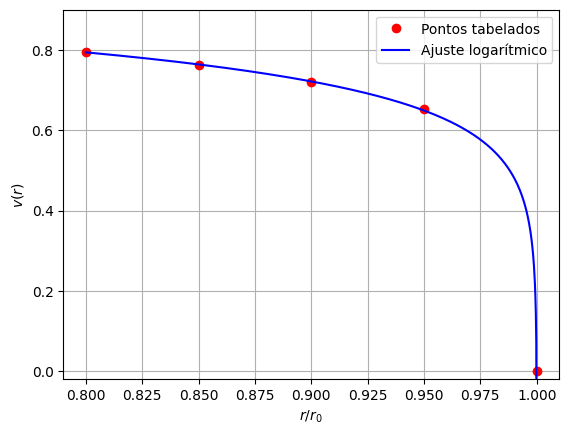

```python
coeff2 = discretepolynfit(newx1, vrvals2, 1)
flog1 = lambda x: coeff2[0] + coeff2[1]*np.log(1.0000001 - x)
xlog1 = np.linspace(0.8, 1.0, 1000)

plt.plot(interval2, vrvals2, "ro", label="$v(r)$")
plt.plot(xlog1, flog1(xlog1), "b-", label="Ajuste linear")
plt.xlabel("$r/r_0$")
plt.ylabel("$v(r)$")
plt.ylim(-0.02, 0.9)
plt.legend(["Pontos tabelados", "Ajuste logarítmico"])
plt.grid()
plt.show()
```

Vamos agora ajustar a segunda função (a que queremos integrar mesmo) e depois comparar tudo com o que obtemos diretamente da função desejada.

```python
interval3 = rvals[0:7]
interval4 = rvals[6:12]
rvrvals1 = rvrvals[0:7]
rvrvals2 = rvrvals[6:12]
```

Importante notar que mudei de um ajuste de polinômio de grau 4 para um polinômio de grau 6 no primeiro subintervalo pois obtive um melhor ajuste assim.

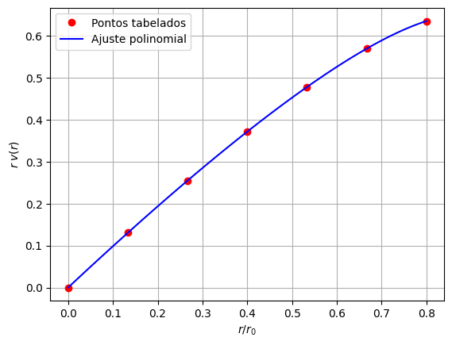

```python
n3 = 6
coeff3 = discretepolynfit(interval3, rvrvals1, n3)
ffourth2 = lambda x: sum([coeff3[i]*x**i for i in range(n3+1)])
xquad2 = np.linspace(interval3[0], interval3[-1], 100)
plt.plot(interval3, rvrvals1, "ro")
plt.plot(xquad2, ffourth2(xquad2), "b-")
plt.xlabel("$r/r_0$")
plt.ylabel("$r \; v(r)$")
plt.legend(["Pontos tabelados", "Ajuste polinomial"])
plt.grid()
plt.show()
```

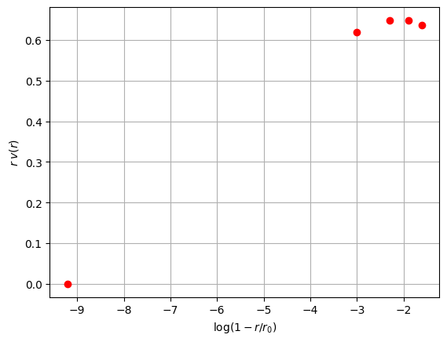

```python
x2 = interval4
xnew2 = np.log(1.0000001 - x2)

plt.plot(xnew2, rvrvals2, 'ro')
plt.xlabel("$\log(1 - r/r_0)$")
plt.ylabel("$r \; v(r)$")
plt.grid()
plt.show()
```

Dessa vez não parece estar tão bem linearizado, mas deve bastar.

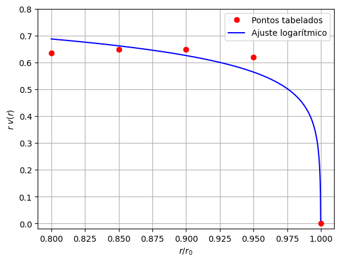

```python
coeff4 = discretepolynfit(xnew2, rvrvals2, 1)
flog2 = lambda x: coeff4[0] + coeff4[1]*np.log(1.0000001 - x)
xlog2 = np.linspace(interval4[0], interval4[-1], 1000)
plt.plot(interval4, rvrvals2, "ro", label="$r \; v(r)$")
plt.plot(xlog2, flog2(xlog2), "b-", label="Ajuste linear")
plt.xlabel("$r/r_0$")
plt.ylabel("$r \; v(r)$")
plt.ylim(-0.02, 0.8)
plt.legend(["Pontos tabelados", "Ajuste logarítmico"])
plt.grid()
plt.show()
```

Juntando e colocando em um mesmo gráfico e comparando com as funções originais:

```python
print(coeff1)
print(coeff2)
print(coeff3)
print(coeff4)
```

```
[1.000 -0.132 -0.167 0.269 -0.319]
[0.962 0.104]
[-0.000 1.002 -0.186 0.214 -0.856 1.139 -0.684]
[0.831 0.089]
```

## Resposta da 3.1

Encontramos os parâmetros para cada respectivo ajuste:

\begin{equation} r v(x = r/r_0) = \begin{cases} 1.002x - 0.186x^2 + 0.214x^3 - 0.856x^4 + 1.139x^5 - 0.684x^6, \quad &\text{se} \quad 0 < x \leq 0.8 \\ 0.089 \ln(1 - x) + 0.831, \quad &\text{se} \quad 0.8 < x < 1. \end{cases} \end{equation}

```python
v = lambda r: b*(1 - r/r0)**(1/7)
rv = lambda r: r*v(r)
```

## Resposta da 3.2

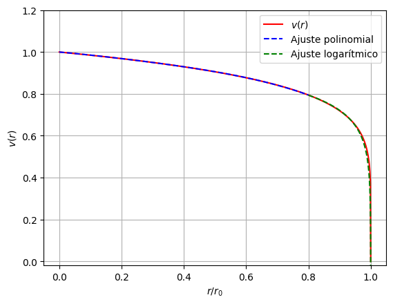

```python
xvr = np.linspace(0, r0, 1000)

plt.plot(xvr, v(xvr), "r-", label="$v(r)$")
plt.plot(xquad1, ffourth1(xquad1), "b--")
plt.plot(xlog1, flog1(xlog1), "g--")
plt.xlabel("$r/r_0$")
plt.ylabel("$v(r)$")
plt.ylim(-0.02, 1.2)
plt.legend(["$v(r)$", "Ajuste polinomial", "Ajuste logarítmico"])
plt.grid()
plt.show()
```

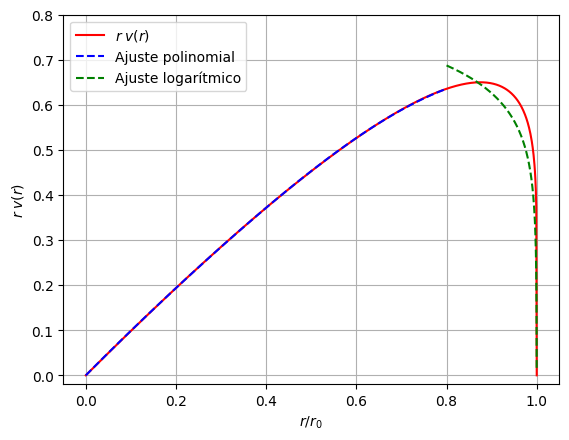

```python
xrvr = np.linspace(0, r0, 1000)

plt.plot(xrvr, rv(xrvr), "r-", label="$r \; v(r)$")
plt.plot(xquad2, ffourth2(xquad2), "b--")
plt.plot(xlog2, flog2(xlog2), "g--")
plt.xlabel("$r/r_0$")
plt.ylabel("$r \; v(r)$")
plt.ylim(-0.02, 0.8)
plt.legend(["$r \; v(r)$", "Ajuste polinomial", "Ajuste logarítmico"])
plt.grid()
plt.show()
```

Eu até tentei ajustar um polinômio e também uma função exponencial no segundo subintervalo, mas por algum motivo eu ainda estava estava obtendo uns ajustes não muito bons (mesmo pra primeira função $v(r)$). No fim o ajuste da primeira função ficou bem bom, o da segunda acho que daria para melhorar retirando mais alguns pontos e podendo mudar os subintervalos, mas acho que não posso fazer isso aqui.

## Resposta 3.3

A integral é:

\begin{equation} Q = 2\pi I, \end{equation} onde \begin{equation} I = \int_0^{r_0} r v(r) dr. \end{equation}

Como temos duas funções ajustadas, quebramos o intervalo:

\begin{equation} I \approx \int_0^{0.8r_0} (1.002x - 0.186x^2 + 0.214x^3 - 0.856x^4 + 1.139x^5 - 0.684x^6)dr + \int_{0.8r_0}^{r_0} \big[ 0.089 \ln(1 - x) + 0.831 \big]dr, \quad x = r/r_0, \; r_0 = 1 \end{equation}

São integrais resolvíveis analiticamente. Obtemos

\begin{equation} I \approx 0.403734 \end{equation} em comparação com o resultado que sabemos \begin{equation} I = 0.4083333... \; . \end{equation}

Novamente, a aproximação polinomial resultou em duas casas decimais de precisão enquanto a integral com o ajuste logarítmico resultou em apenas uma casa decimal de precisão (cálculos feitos no Wolfram Alpha).

A equação diferencial encontrada é:

\begin{equation} \left\{ \begin{array}{l} 2y' = 1 + \frac{y}{2x}, x \in [1,2] \\ y(1) = 2, (h = 0,05) \end{array} \right. . \end{equation}

Essa EDO tem solução analítica

\begin{equation} y(x) = \frac{2}{3}(2 x^{1/4} + x) \end{equation}

```python
yf = lambda x: 2.0*(2*x**(1/4) + x)/3.0
```

```python
#código feito para solução de edos
#não tem nenhum algorítmo explícito na apostila, mas utilizei o texto nela como base
def euler(f, x0, y0, h, n):
    #floor não funciona muito bem por causa de divisões estranhas de floats, ex: 0.3/0.1 = 2.9999999999999996
    x = np.zeros(n+1)
    y = np.zeros(n+1)
    x[0] = x0
    y[0] = y0
    for i in range(1,n+1):
        x[i] = x[i-1] + h
        y[i] = y[i-1] + h*f(x[i-1],y[i-1])

    return (x,y)

def heun(f, x0, y0, h, n):
    x = np.zeros(n+1)
    y = np.zeros(n+1)
    x[0] = x0
    y[0] = y0
    for i in range(1,n+1):
        K1 = f(x[i-1], y[i-1])
        K2 = f(x[i-1] + h/3.0, y[i-1] + h*K1/3.0)
        K3 = f(x[i-1] + 2.0*h/3.0, y[i-1] + 2.0*h*K2/3.0)
        y[i] = y[i-1] + h*(K1 + 3.0*K3)/4.0
        x[i] = x[i-1] + h

    return (x,y)

#é facilmente generalizado para sistemas de equações diferenciais
def rk4(f, x0, y0, h, n):
    x = np.zeros(n+1)
    y = np.zeros(n+1)
    x[0] = x0
    y[0] = y0
    for i in range(1,n+1):
        K1 = f(x[i-1], y[i-1])
        K2 = f(x[i-1] + h/2.0, y[i-1] + h*K1/2.0)
        K3 = f(x[i-1] + h/2.0, y[i-1] + h*K2/2.0)
        K4 = f(x[i-1] + h, y[i-1] + h*K3)
        y[i] = y[i-1] + h*(K1 + 2.0*K2 + 2.0*K3 + K4)/6.0
        x[i] = x[i-1] + h

    return (x,y)
```

```python
n = 20
x0 = 1.0
y0 = 2.0
f = lambda x,y: 0.5 + y/(4.0*x)
h = 0.05
x, y = heun(f, x0, y0, h, n)
```

```python
print(x)
print(y)
print(yf(x))
```

```
[1.000 1.050 1.100 1.150 1.200 1.250 1.300 1.350 1.400 1.450 1.500 1.550
 1.600 1.650 1.700 1.750 1.800 1.850 1.900 1.950 2.000]
[2.000 2.050 2.099 2.147 2.196 2.243 2.290 2.337 2.384 2.430 2.476 2.521
 2.566 2.611 2.656 2.700 2.744 2.788 2.832 2.876 2.919]
[2.000 2.050 2.099 2.147 2.196 2.243 2.290 2.337 2.384 2.430 2.476 2.521
 2.566 2.611 2.656 2.700 2.744 2.788 2.832 2.876 2.919]
```

```python
print("n \t x_(n+1) \t y_(n+1) \t y_E \t\t erro absoluto")
for i in range(1,n+1, 10):
    print("%d \t %.4f \t %.4f \t %.4f \t %.4f"%(i, x[i], y[i], yf(x[i]), abs(y[i] - yf(x[i]))))
```

```
n 	 x_(n+1) 	 y_(n+1) 	 y_E 		 erro absoluto
1 	 1.0500 	 2.0497 	 2.0497 	 0.0000
11 	 1.5500 	 2.5211 	 2.5211 	 0.0000
```

Agora começando da solução y_0

```python
print("n \t x_(n+1) \t y_(n+1) \t y_E \t\t erro absoluto")
for i in range(0,n+1, 10):
    print("%d \t %.4f \t %.4f \t %.4f \t %.4f"%(i, x[i], y[i], yf(x[i]), abs(y[i] - yf(x[i]))))
```

```
n 	 x_(n+1) 	 y_(n+1) 	 y_E 		 erro absoluto
0 	 1.0000 	 2.0000 	 2.0000 	 0.0000
10 	 1.5000 	 2.4756 	 2.4756 	 0.0000
20 	 2.0000 	 2.9189 	 2.9189 	 0.0000
```

Agora de 5 em 5:

```python
print("n \t x_(n+1) \t y_(n+1) \t y_E \t\t erro absoluto")
for i in range(1,n+1, 5):
    print("%d \t %.4f \t %.4f \t %.4f \t %.4f"%(i, x[i], y[i], yf(x[i]), abs(y[i] - yf(x[i]))))
```

```
n 	 x_(n+1) 	 y_(n+1) 	 y_E 		 erro absoluto
1 	 1.0500 	 2.0497 	 2.0497 	 0.0000
6 	 1.3000 	 2.2904 	 2.2904 	 0.0000
11 	 1.5500 	 2.5211 	 2.5211 	 0.0000
16 	 1.8000 	 2.7444 	 2.7444 	 0.0000
```

```python
print("n \t x_(n+1) \t y_(n+1) \t y_E \t\t erro absoluto")
for i in range(0,n+1, 5):
    print("%d \t %.4f \t %.4f \t %.4f \t %.4f"%(i, x[i], y[i], yf(x[i]), abs(y[i] - yf(x[i]))))
```

```
n 	 x_(n+1) 	 y_(n+1) 	 y_E 		 erro absoluto
0 	 1.0000 	 2.0000 	 2.0000 	 0.0000
5 	 1.2500 	 2.2432 	 2.2432 	 0.0000
10 	 1.5000 	 2.4756 	 2.4756 	 0.0000
15 	 1.7500 	 2.7002 	 2.7002 	 0.0000
20 	 2.0000 	 2.9189 	 2.9189 	 0.0000
```

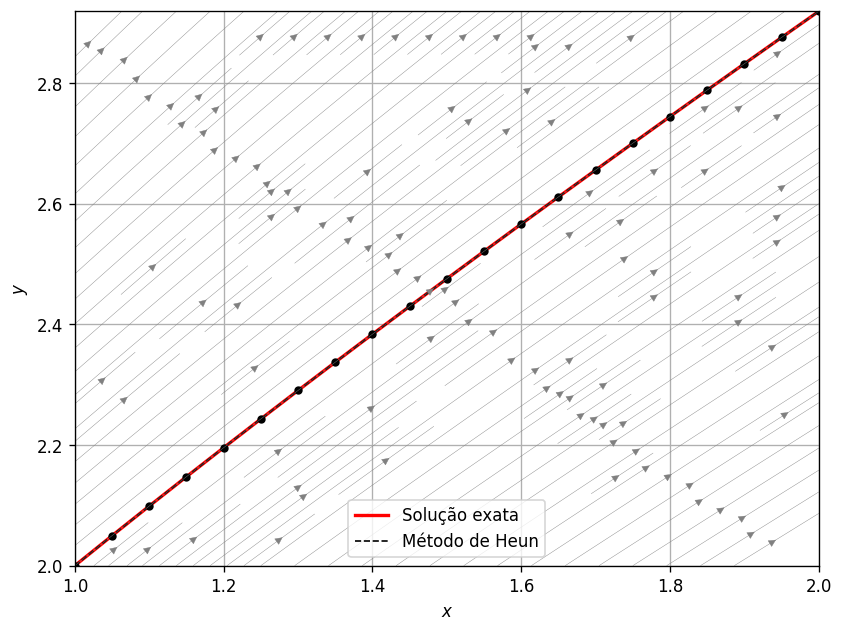

```python
xmesh = np.linspace(min(x), max(x), 100)
ymesh = np.linspace(min(y), max(y), 100)

Xl, Yl = np.meshgrid(xmesh, ymesh)
P = Xl/Xl
Q = 0.5 + Yl/(4.0*Xl)

fig = plt.figure(figsize=(8, 6), dpi=120)

plt.plot(x, yf(x), "r-", label="Solução exata", lw=2)
plt.plot(x, y, "k--", label="Método de Heun", lw=1)
plt.plot(x, y, "ko", ms=4)

plt.streamplot(Xl, Yl, P, Q, density=1.5, color="gray", linewidth=0.25)

plt.xlabel("$x$")
plt.ylabel("$y$")
plt.legend(["Solução exata", "Método de Heun"])
plt.grid()
plt.show()
```